# Análise Exploratória de Dados do e-SUS

Sandro Silva

26/07/2020

# Descrição da atividade

Os dados dessa análise exploratória foram coletados do e-SUS Notifica, que possui informações de notificações de suspeitos e confirmados de COVID-19 nos municípios do estado da Paraíba.

# Carregando os dados

Visão geral dos dados:

```
Rows: 263,177
Columns: 33
$ id                         <fct> 8qBdtBv7vS, NOOFMuVIYZ, ieblZ27mjN, 6glS...
$ data_notificacao           <date> 2020-05-21, 2020-05-21, 2020-05-21, 202...
$ data_inicio_sintomas       <date> 2020-05-05, 2020-05-12, 2020-05-18, 202...
$ data_nascimento            <date> 1979-10-11, 1989-01-02, 2001-11-01, 202...
$ sintomas                   <fct> "Dor de Garganta, Tosse, Outros", "Febre...
$ profissional_saude         <fct> Não, Não, Não, Não, Não, Não, Não, Não, ...
$ cbo                        <fct> NA, NA, NA, NA, NA, NA, NA, NA, NA, "515...
$ condicoes                  <fct> "Doenças respiratórias crônicas descompe...
$ estado_teste               <fct> NA, NA, NA, Concluído, Solicitado, Solic...
$ data_teste                 <date> NA, NA, NA, 2020-05-18, NA, NA, 2020-05...
$ tipo_teste                 <fct> NA, NA, NA, TESTE RÁPIDO - ANTICORPO, NA...
$ resultado_teste            <fct> NA, NA, NA, Positivo, NA, NA, Negativo, ...
$ pais_origem                <lgl> NA, NA, NA, NA, NA, NA, NA, NA, NA, NA, ...
```

[output cut: 20 more lines]

# Alguns atributos explorados

## Tipos, resultados e estados dos teste

A coluna `resultado_teste` informa se o teste para COVID-19 foi Positivo, Negativo ou *NA* se ainda não há resultado registrado. A quantidade e percentual de cada um foi:

```
# A tibble: 3 x 3
  resultado_teste quantidade percentual
  <fct>                <int> <chr>
1 Negativo            131580 50%
2 Positivo             66382 25%
3 <NA>                 65215 25%
```

Observamos que aproximadamente metade dos notificados testaram negativo, 25% testaram positivo e os outros 25% não possuem resultado de teste.

A tabela `tipo_teste` indica qual tipo de teste para COVID-19 foi realizado. Notamos que o maior percentual foi do tipo Teste Rápido - Anticorpo, com 64% do tipo de testes realizados.

```
# A tibble: 6 x 3
  tipo_teste                                            quantidade percentual
  <fct>                                                      <int> <chr>
1 Enzimaimunoensaio - ELISA IgM                                132 0%
2 Imunoensaio por Eletroquimioluminescência - ECLIA IgG        570 0%
3 RT-PCR                                                     14034 5%
4 TESTE RÁPIDO - ANTICORPO                                  168364 64%
5 TESTE RÁPIDO - ANTÍGENO                                    14863 6%
6 <NA>                                                       65214 25%
```

A tabela `estado_teste` indica se o teste foi coletado, concluído, solicitado ou não solicitado. Observamos que 75% dos testes foram concluídos.

```
# A tibble: 5 x 3
  estado_teste         quantidade percentual
  <fct>                     <int> <chr>
1 Coletado                   6895 3%
2 Concluído                197964 75%
3 Exame Não Solicitado       1924 1%
4 Solicitado                32059 12%
5 <NA>                      24335 9%
```

## Idade, sexo, profissão, localidade, comorbidades

A coluna `idade` informa a idade de cada paciente registrado.

Estatísticas das idades dos pacientes registrados:

```
   Min. 1st Qu.  Median    Mean 3rd Qu.    Max.    NA's
    0.0    28.0    38.0    39.2    49.0   387.0       8
```

Podemos gerar um box-plot para visualizar as idades:

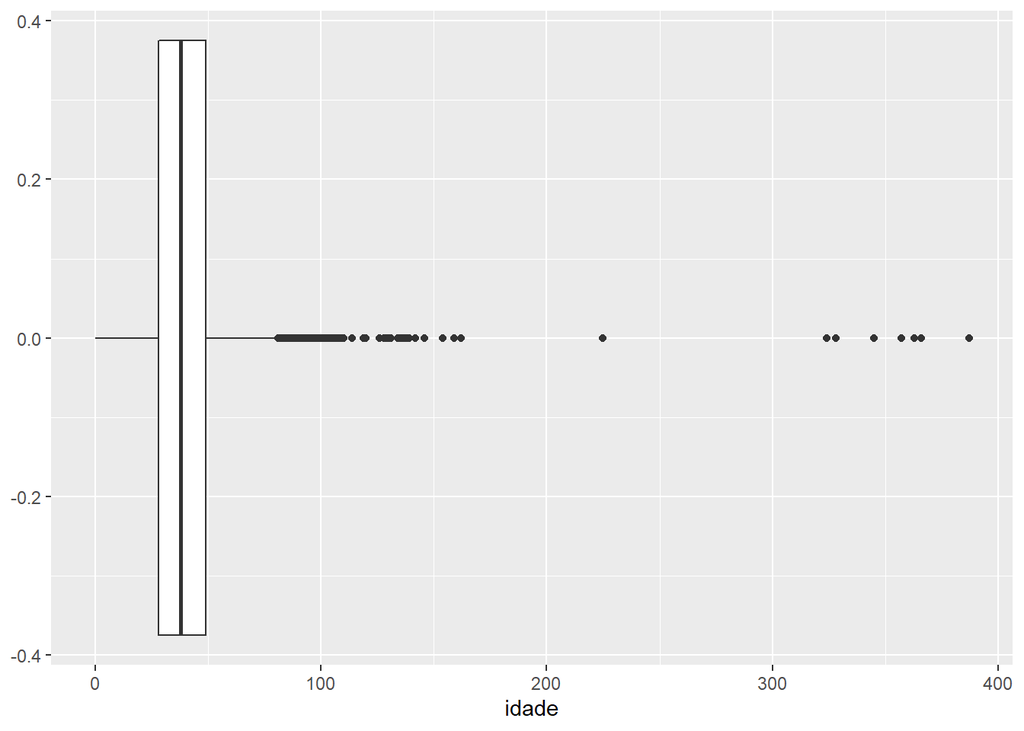

O gráfico de barras abaixo apresenta a frequência de casos da Covid-19 de crianças na faixa etária de 0 a 12 anos de idade.

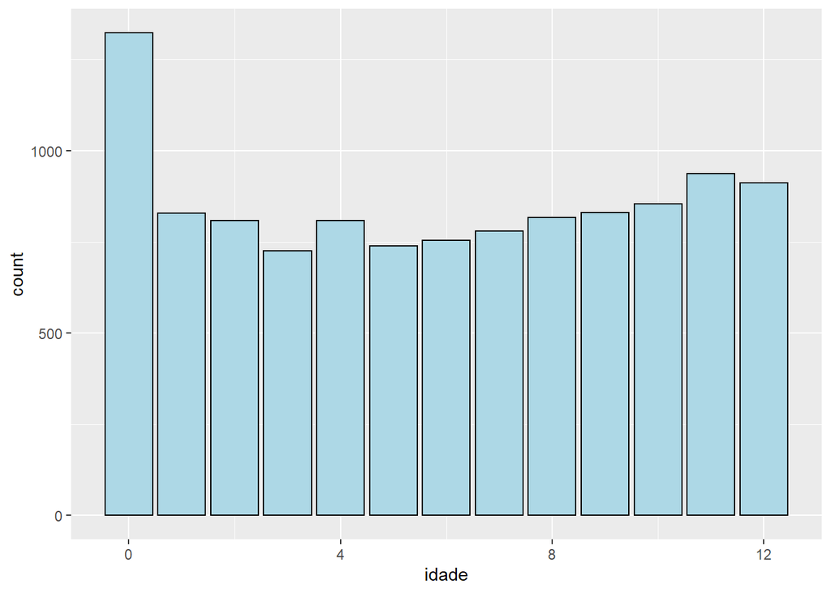

O gráfico de barras abaixo apresenta a frequência de casos da Covid-19 de idosos a partir de 60 anos de idade.

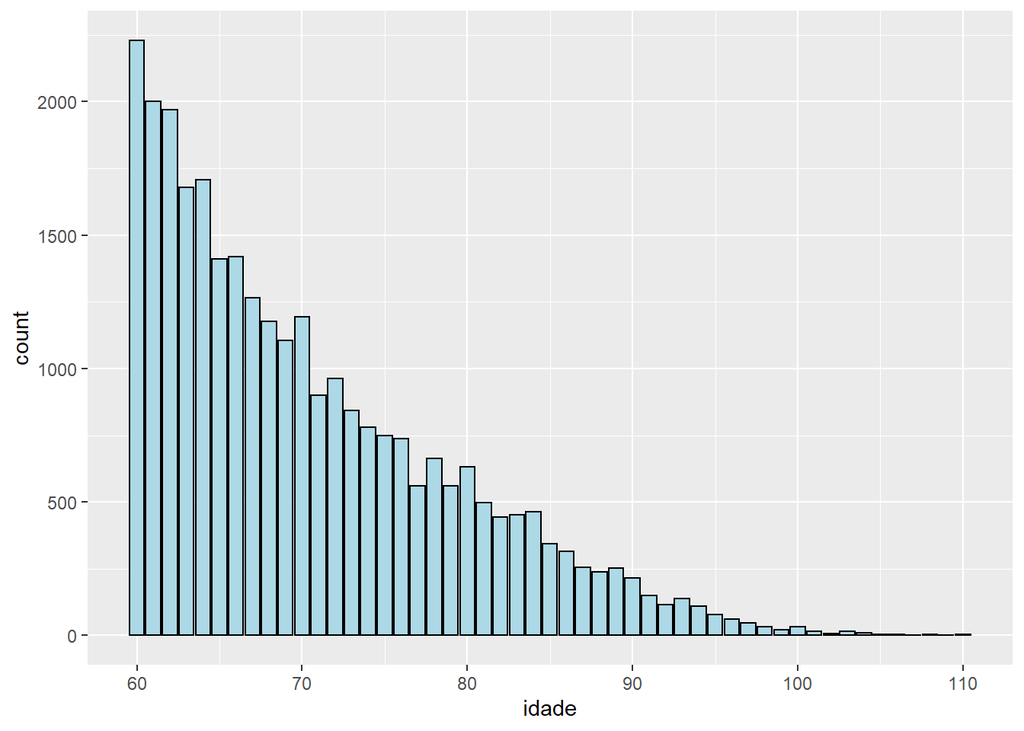

A tabela abaixo apresenta as profissões em que ocorreram casos da Covid-19.

```
# A tibble: 55 x 3
   cbo                                                     quantidade percentual
   <fct>                                                        <int> <chr>
 1 1312 - Gestores e especialistas de operações em empres~        595 0%
 2 2011 - Profissional da Biotecnologia                            11 0%
 3 2030 - Pesquisador das ciências biológicas                      14 0%
 4 2131 - Físico atuando na área da saúde                          58 0%
 5 2132 - Químico atuando na área da saúde                          6 0%
 6 2149 - Engenheiro de Segurança do Trabalho ou Higienis~         21 0%
 7 2211 - Biólogo                                                  10 0%
 8 2212 - Biomédico                                               214 0%
 9 222205 - Engenheiro de Alimentos                                 8 0%
10 2232 - Cirurgião-Dentista                                     1073 0%
# ... with 45 more rows
```

A tabela abaixo apresenta as quantidades e percentuais por municipios. Onde se destacam João Pessoa com 30% e Campina Garnde com 10% dos casos.

```
# A tibble: 247 x 3
   municipio           quantidade percentual
   <fct>                    <int> <chr>
 1 25                           5 0%
 2 Água Branca                272 0%
 3 Aguiar                     296 0%
 4 Alagoa Grande             1918 1%
 5 Alagoa Nova                638 0%
 6 Alagoinha                 1472 1%
 7 Alcantil                   366 0%
 8 Algodão de Jandaíra        144 0%
 9 Alhandra                  1240 0%
10 Amparo                     125 0%
# ... with 237 more rows
```

A tabela abaixo apresenta as comordidades de pacientes com Covid-19. Que indica as doenças prévias do paciente, que podem ser fator de risco.

```
# A tibble: 159 x 3
   condicoes                                               quantidade percentual
   <fct>                                                        <int> <chr>
 1 Diabetes                                                      4559 2%
 2 Diabetes, Doenças cardíacas crônicas                          2003 1%
 3 Diabetes, Doenças cardíacas crônicas, Doenças renais c~         12 0%
 4 Diabetes, Doenças cardíacas crônicas, Doenças respirat~         20 0%
 5 Diabetes, Doenças cardíacas crônicas, Gestante                   2 0%
 6 Diabetes, Doenças cardíacas crônicas, Imunossupressão           10 0%
 7 Diabetes, Doenças cardíacas crônicas, Imunossupressão,~          1 0%
 8 Diabetes, Doenças cardíacas crônicas, Portador de doen~          5 0%
 9 Diabetes, Doenças cardíacas crônicas, Portador de doen~          1 0%
10 Diabetes, Doenças renais crônicas em estágio avançado ~         40 0%
# ... with 149 more rows
```

# Percentuais de Homens e Mulheres

```
# A tibble: 3 x 3
  sexo      quantidade percentual
  <fct>          <int> <chr>
1 Feminino      145068 55%
2 Masculino     118106 45%
3 <NA>               3 0%
```

# Percentuais de Profissionais de Saúde

```
# A tibble: 3 x 3
  profissional_saude quantidade percentual
  <fct>                   <int> <chr>
1 Não                    227493 86%
2 Sim                     35626 14%
3 <NA>                       58 0%
```